# Raptor-Incidents

Oxygen

21 06 2021

# Raptor Persecution Incidents

### Buse Küçükçoban, Defne Bayrak

Unfortunately the cruel attitudes of humankind towards animals are known through history in various categorizations of species, particularly where the wild animals are concerned. Since the intensity and significance of human animal interactions directly affect how people value animal life, it is quite obvious to claim that raptors are one of the endangered species that suffer the most [1]. They can be deliberately trapped, or poisoned causing great suffering. In this project, we are working on Raptor Persecution Incidents. The dataset contains details and locations of confirmed raptor persecution incidents in the UK from 2007 to 2019. Our goal is to create awareness with this project because we are aware of the commercials about animal protection all over the world, however when it comes to less popular kinds of animals, the awareness level gets pretty lower and something must be done because hunting is animal cruelty.[2] The data we are using are collated by the RSPB Investigations Team, a specialist unit set up to assist the statutory agencies with the investigation and prosecution of crimes against wild birds. These data are the most complete centralised set of known confirmed raptor persecution incident data for the UK, and has been recorded consistently for several decades. Only the highest evidentially weighted incidents those classified as “confirmed” are included here [3].

```r
library("tidyverse")
library("ggplot2")
library("dplyr")
library("gapminder")
library("tm")
library("tmap")
```

```r
data = read.csv("C:\\Users\\asus\\Desktop\\final_docs-busekcoban\\Confirmed_Raptor_Persecution_Incidents__Public_.csv" , sep= ",")
```

## Data is accessible at:

[Our Data Source Link](https://opendata-rspb.opendata.arcgis.com/datasets/ac7245710c304483a62a0bc3670199db_0?geometry=-32.652%2C49.784%2C26.630%2C58.725)

Our data have changed after project proposal in order to find a more social problem-based content. So, we are going to make a different analysis than the one mentioned in our proposal. The preliminary results of the actions taken so far:

```r
# summary(data)
```

```r
# str(data)
```

The data consists of 5 numeric and 7 char structures.

We hid the columns we don’t need

```r
data = subset(data,select=-c(More_Info_Here,GlobalID,RSPB_Reference))
```

### Null value check:

```r
sum(is.na(data))
```

```
## [1] 0
```

There is no null value in our data

```r
colnames(data)[1] <- "ObjectId"
data$ObjectId <- as.numeric(data$ObjectId)
```

## Arrangement of some columns:

We wanted to show the Ractors involved in the incidents in the “Details” column as a separate column.

Since the “Details” column is in the form of a sentence, we made the necessary separations and added a new column named “Species”

```r
 a <- data %>%
  separate(Details,into = c("Species","Info"), sep = ";")
b <- a %>%
  separate(Species,into = c("Animals","Name"), sep = ":")
 d <- a %>%
  separate(Species,into = c("Ignore1","Ignore2","Name","Name2","Name3"), sep = " ")
 final <- mutate(d,Species = paste(Name,Name2,Name3))
```

```r
stopwords = c("x","1","2","NA",",","Species","4","5","3",".")
x  = final$Species
x  =  removeWords(x,stopwords)
final$Species <- x
data <- data %>%
  mutate(Species = final$Species)
```

```r
data$Species <- names(data$Species) <- gsub("\\.", "",data$Species, perl=TRUE)
```

Since we do not need the detail column, we have hidden it.

```r
data = subset(data,select=-c(Details))
```

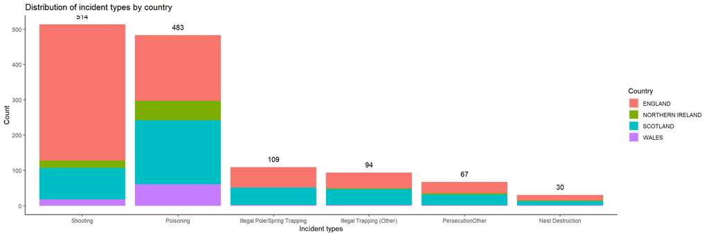

```r
plot1 <- ggplot(data, aes(reorder(Incident_Type,-table(Incident_Type)[Incident_Type]))) +
  geom_bar(aes(fill = Country),size=3) +
  geom_text(stat='count',
                                                   aes(label=..count..), vjust=-1) +
  theme(panel.grid.major = element_blank(),
        panel.grid.minor = element_blank(),
panel.background = element_blank(),
axis.line = element_line(colour = "black"))+
  scale_x_discrete(name ="Incident types")+
  labs(title="Distribution of incident types by country",y="Count")
plot1
```

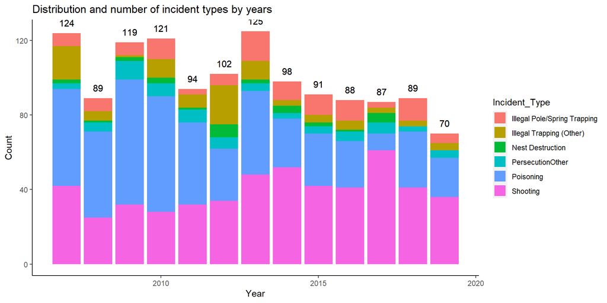

```r
plot2 <- ggplot(data,aes(Year)) +geom_bar(aes(fill=Incident_Type),
                                          size = 3) +
  geom_text(stat='count', aes(label=..count..), vjust=-1) + theme(panel.grid.major = element_blank(),
                                                                  panel.grid.minor = element_blank(),
panel.background = element_blank(),
axis.line = element_line(colour = "black")) +
  geom_text(stat='count',
            aes(label=..count..), vjust=-1) +
  labs(title="Distribution and number of incident types by years",y="Count")
plot2
```

>> From 2007 to 2019, we can say that the lowest incidents were in 2019, even if we did not observe a constant decrease. Every year we see poisoning or being shot head-on.

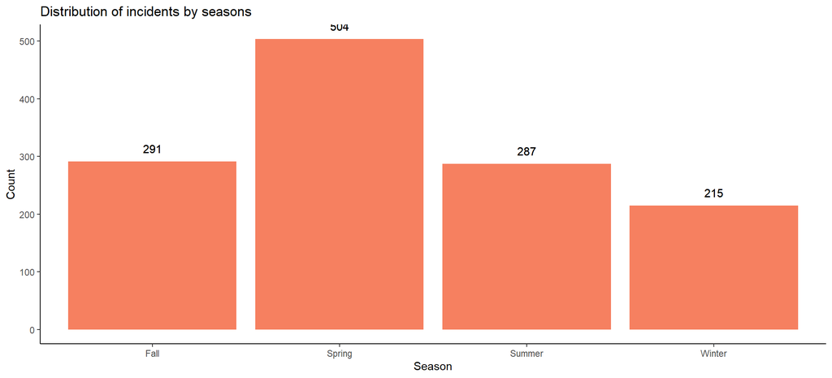

```r
data <- data %>%
  mutate(Season = case_when(
      Month == "September"|Month == "October" | Month == "November"~ "Fall",
      Month == "January"|Month == "February" |Month == "December"   ~ "Winter",
      Month == "March"|Month == "April"|Month == "May"   ~ "Spring",
      TRUE ~ "Summer"))
plot3 <- ggplot(data,aes(Season)) +
  geom_bar(size = 1,fill = "#f68060") +
  geom_text(stat='count', aes(label=..count..), vjust=-1)+ theme(panel.grid.major = element_blank(),
                                                                 panel.grid.minor = element_blank(),
panel.background = element_blank(),
axis.line = element_line(colour = "black")) +
  geom_text(stat='count', aes(label=..count..), vjust=-1)+
  labs(title="Distribution of incidents by seasons",y="Count")
plot3
```

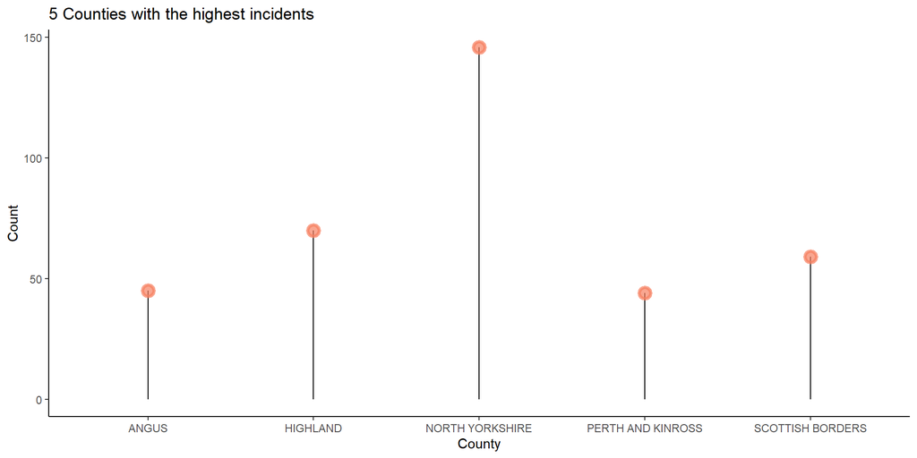

```r
data2 <- data %>%
  group_by(County) %>%
  summarise(distinct_values = n_distinct(ObjectId))
data3 <- data2 %>%
  arrange(desc(distinct_values))
data3 <- head(data3,5)
plot4 <- ggplot(data3,aes(County,distinct_values)) +
  geom_segment(aes(x=County, xend=County, y=0, yend=distinct_values)) +
  geom_point(size=3, color="#f68060", fill=alpha("#f68060", 0.3), alpha=0.7, shape=21, stroke=2) +
  theme(panel.grid.major = element_blank(),
        panel.grid.minor = element_blank(),
panel.background = element_blank(),
axis.line = element_line(colour = "black"))+
  labs(title="5 Counties with the highest incidents",y="Count")
plot4
```

>> Angus, Highland, North Yorkshire, Perth and Kinross and Scottish Borders are one of the counties where the incidents took place the most.

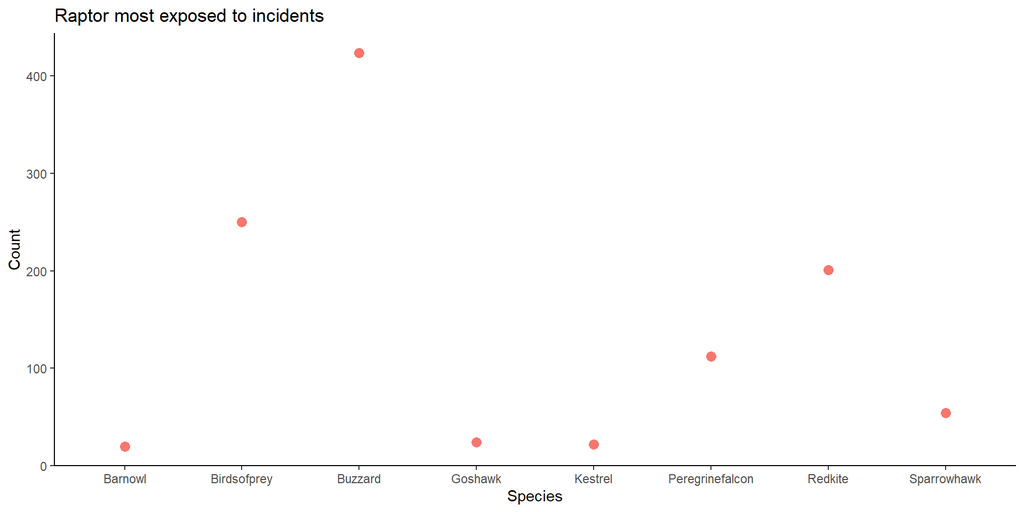

```r
data3 <- data %>%
  group_by(Species) %>%
  summarise(distinct_values = n_distinct(ObjectId))
data4 <- data3 %>%
  arrange(desc(distinct_values))
data4 <- head(data4,8)
plot5 <- ggplot(data4,aes(Species,distinct_values, color ="#f68060")) + geom_point(size=3) +
  theme(panel.grid.major = element_blank(), panel.grid.minor = element_blank(),
panel.background = element_blank(), legend.position = "none",
axis.line = element_line(colour = "black"))+
  labs(title="Raptor most exposed to incidents",y="Count")
plot5
```

> > Buzzards, other birds of prey and red kites are among the most exposed creatures.

```r
library(sf)

uk0 <- st_read("C:\\Users\\asus\\Desktop\\final_docs-busekcoban\\shp\\NUTS_Level_2_(January_2018)_Boundaries.shp")
library(tmap)
# tmap_mode("view")
uk <- readRDS("C:\\Users\\asus\\Desktop\\final_docs-busekcoban\\shp\\gadm36_GBR_2_sf.rds")
# view(uk)
```

```r
# plot(st_geometry(uk))
# st_crs(uk)
```

```r
library(dplyr)
library(tmap)
# uk %>%
# tm_shape() +
#   tm_dots() +
#   tm_basemap("OpenStreetMap")
```

```r
uk <- uk %>%
  rename(County = NAME_2) %>%
  select(County)
```

We made some corrections so that some names are the same.

```r
uk$County <- toupper(uk$County)
uk$County[130] = "ABERDEENSHIRE"
uk$County[119] = "ANTRIM"
uk$County[122] = "ARMAGH"
uk$County[29] = "ACHESHIRE"
uk$County[30] = "CHESHIRE"
uk$County[43] = "COUNTY DURHAM"
uk$County[43] = "COUNTY DURHAM"
uk$County[43] = "COUNTY DURHAM"
uk$County[43] = "COUNTY DURHAM"
```

Merging two datas.

```r
mapping <- merge(uk,data,by="County")
st_crs(mapping)
```

```
## Coordinate Reference System:
##   User input: EPSG:4326
##   wkt:
## GEOGCRS["WGS 84",
##     DATUM["World Geodetic System 1984",
##         ELLIPSOID["WGS 84",6378137,298.257223563,
##             LENGTHUNIT["metre",1]]],
##     PRIMEM["Greenwich",0,
##         ANGLEUNIT["degree",0.0174532925199433]],
##     CS[ellipsoidal,2],
##         AXIS["geodetic latitude (Lat)",north,
##             ORDER[1],
##             ANGLEUNIT["degree",0.0174532925199433]],
##         AXIS["geodetic longitude (Lon)",east,
##             ORDER[2],
##             ANGLEUNIT["degree",0.0174532925199433]],
##     USAGE[
##         SCOPE["Horizontal component of 3D system."],
##         AREA["World."],
##         BBOX[-90,-180,90,180]],
##     ID["EPSG",4326]]
```

```r
mapping <- mapping %>%
  select(County,Season)
```

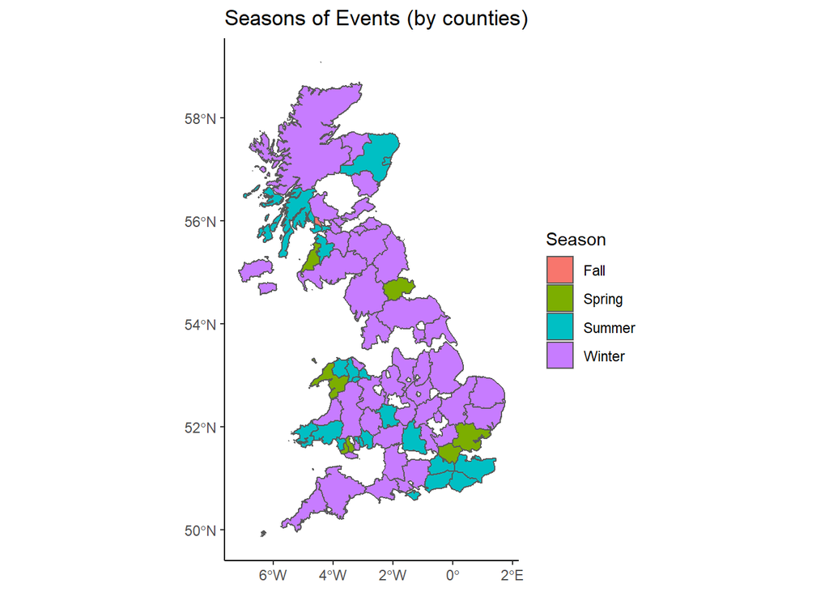

```r
library(ggplot2)
plot_map <- ggplot(mapping) +
   geom_sf(aes(fill = Season)) +
  theme(panel.grid.major = element_blank(),
        panel.grid.minor = element_blank(),
panel.background = element_blank(),
axis.line = element_line(colour = "black"))+
  labs(title="Seasons of Events (by counties)")
plot_map
```

> > Although the most incidents occurred in spring and autumn, we see that incidents occur in almost every district in winter.

(We could not show some parts on the map because the rds file we have with the shapefile does not contain counties)

## Results and Discussion:

According to the analysis we have done, we observed that poisoning and shooting are the most common raptor persecutions that occured in the UK. Those persecutions are mostly taking place in the hunting season and since the hunting ratio increases while the birds are breeding, this so-called “entertainment” causes raptors to suffer and also endanger the animals and the ecosystem.

## Conclusion:

In this project, we’ve observed the cruel attitudes of humankind towards raptors in the United Kingdom by using a dataset contains details and locations of confirmed raptor persecution incidents from 2007 to 2019. In conclusion, since our main goal on this project is to create awareness about animal cruelty with hunting, we have done the mappings and also continued the data visualization. We aimed to make it easier to understand the data with the help of visual details.

## References:

[1] https://www.cambridge.org/core/services/aop-cambridge-core/content/view/0B248814FBB82A6953DA31487AAB8168/ S0030605305000797a.pdf/history_of_organized_persecution_and_conservation_of_wildlife_species_ categorizations_in_finnish_legislation_from_medieval_times_to_1923.pdf

[2] https://www.worldanimalprotection.org.uk/campaigns/animals-wild/wildlife-crime-in-uk

[3] https://opendata-rspb.opendata.arcgis.com/datasets/confirmed-raptor-persecution-incidents-includingunmappable- incidents-public